# hw06

Patricia T. Angkiriwang

November 8, 2018

# Part One: Halloween Candy (Topic #3)

Prompted by a [homework assignment from 2015](http://stat545.com/Classroom/assignments/hw06/references/2015_hw.html), we explore a dataset based on a [Halloween candy survey](https://github.com/jennybc/candy).

Here, the data used is the latest (2017) candy data from the [Science Creative Quarterly](http://www.scq.ubc.ca/so-much-candy-data-seriously/), talked about [here](https://boingboing.net/2017/10/30/the-2017-halloween-candy-hiera.html).

In this exercise, we’ll:

1. Explore raw data,
2. Get it into a workable format (guided by [2015 class notes](https://github.com/jennybc/candy/blob/master/data-raw/00_explore-raw.md)), and
3. Plot and Analyse (compare different types of candy, create graph similar to that in [Science Creative Quarterly](http://www.scq.ubc.ca/so-much-candy-data-seriously/), and other analyses)

Other analyses of this “candy hierarchy” data found on the web acted as inspiration and references for this work:

- http://www.shanellis.com/blog/data-driven-decision-making-halloween-candy-edition/#disqus_thread
- https://gist.github.com/EmilHvitfeldt/6d936c8af4d2dd1556669d367f0a6056
- https://github.com/phoebewong/candy-hierarchy-2017/blob/master/candy_analysis.md

```r
suppressPackageStartupMessages(library(tidyverse)) # Loads purrr, too
suppressPackageStartupMessages(library(testthat))
library(stringr)
library(readxl)
require(janitor) # for cleaning strings
```

### 1. What does the raw data look like?

Let’s import and take a look at the excel file. Check the number of rows, and what the column names look like.

```r
raw <- read_excel("candyhierarchy2017.xlsx")
head(raw)
```

```
## # A tibble: 6 x 120
##   `Internal ID` `Q1: GOING OUT?` `Q2: GENDER` `Q3: AGE` `Q4: COUNTRY`
##           <dbl> <chr>            <chr>        <chr>     <chr>
## 1      90258773 <NA>             <NA>         <NA>      <NA>
## 2      90272821 No               Male         44        USA
## 3      90272829 <NA>             Male         49        USA
## 4      90272840 No               Male         40        us
## 5      90272841 No               Male         23        usa
## 6      90272852 No               Male         <NA>      <NA>
## # ... with 115 more variables: `Q5: STATE, PROVINCE, COUNTY, ETC` <chr>,
## #   `Q6 | 100 Grand Bar` <chr>, `Q6 | Anonymous brown globs that come in
## #   black and orange wrappers\t(a.k.a. Mary Janes)` <chr>, `Q6 | Any
## #   full-sized candy bar` <chr>, `Q6 | Black Jacks` <chr>, `Q6 | Bonkers
## #   (the candy)` <chr>, `Q6 | Bonkers (the board game)` <chr>, `Q6 |
## #   Bottle Caps` <chr>, `Q6 | Box'o'Raisins` <chr>, `Q6 | Broken glow
## #   stick` <chr>, `Q6 | Butterfinger` <chr>, `Q6 | Cadbury Creme
## #   Eggs` <chr>, `Q6 | Candy Corn` <chr>, `Q6 | Candy that is clearly just
## #   the stuff given out for free at restaurants` <chr>, `Q6 |
## #   Caramellos` <chr>, `Q6 | Cash, or other forms of legal tender` <chr>,
## #   `Q6 | Chardonnay` <chr>, `Q6 | Chick-o-Sticks (we don’t know what that
## #   is)` <chr>, `Q6 | Chiclets` <chr>, `Q6 | Coffee Crisp` <chr>, `Q6 |
## #   Creepy Religious comics/Chick Tracts` <chr>, `Q6 | Dental
## #   paraphenalia` <chr>, `Q6 | Dots` <chr>, `Q6 | Dove Bars` <chr>, `Q6 |
## #   Fuzzy Peaches` <chr>, `Q6 | Generic Brand Acetaminophen` <chr>, `Q6 |
## #   Glow sticks` <chr>, `Q6 | Goo Goo Clusters` <chr>, `Q6 | Good N'
## #   Plenty` <chr>, `Q6 | Gum from baseball cards` <chr>, `Q6 | Gummy Bears
## #   straight up` <chr>, `Q6 | Hard Candy` <chr>, `Q6 | Healthy
## #   Fruit` <chr>, `Q6 | Heath Bar` <chr>, `Q6 | Hershey's Dark
## #   Chocolate` <chr>, `Q6 | Hershey’s Milk Chocolate` <chr>, `Q6 |
## #   Hershey's Kisses` <chr>, `Q6 | Hugs (actual physical hugs)` <chr>, `Q6
## #   | Jolly Rancher (bad flavor)` <chr>, `Q6 | Jolly Ranchers (good
## #   flavor)` <chr>, `Q6 | JoyJoy (Mit Iodine!)` <chr>, `Q6 | Junior
## #   Mints` <chr>, `Q6 | Senior Mints` <chr>, `Q6 | Kale smoothie` <chr>,
## #   `Q6 | Kinder Happy Hippo` <chr>, `Q6 | Kit Kat` <chr>, `Q6 |
## #   LaffyTaffy` <chr>, `Q6 | LemonHeads` <chr>, `Q6 | Licorice (not
## #   black)` <chr>, `Q6 | Licorice (yes black)` <chr>, `Q6 | Lindt
## #   Truffle` <chr>, `Q6 | Lollipops` <chr>, `Q6 | Mars` <chr>, `Q6 |
## #   Maynards` <chr>, `Q6 | Mike and Ike` <chr>, `Q6 | Milk Duds` <chr>,
## #   `Q6 | Milky Way` <chr>, `Q6 | Regular M&Ms` <chr>, `Q6 | Peanut
## #   M&M’s` <chr>, `Q6 | Blue M&M's` <chr>, `Q6 | Red M&M's` <chr>, `Q6 |
## #   Green Party M&M's` <chr>, `Q6 | Independent M&M's` <chr>, `Q6 |
## #   Abstained from M&M'ing.` <chr>, `Q6 | Minibags of chips` <chr>, `Q6 |
## #   Mint Kisses` <chr>, `Q6 | Mint Juleps` <chr>, `Q6 | Mr.
## #   Goodbar` <chr>, `Q6 | Necco Wafers` <chr>, `Q6 | Nerds` <chr>, `Q6 |
## #   Nestle Crunch` <chr>, `Q6 | Now'n'Laters` <chr>, `Q6 | Peeps` <chr>,
## #   `Q6 | Pencils` <chr>, `Q6 | Pixy Stix` <chr>, `Q6 | Real Housewives of
## #   Orange County Season 9 Blue-Ray` <chr>, `Q6 | Reese’s Peanut Butter
## #   Cups` <chr>, `Q6 | Reese's Pieces` <chr>, `Q6 | Reggie Jackson
## #   Bar` <chr>, `Q6 | Rolos` <chr>, `Q6 | Sandwich-sized bags filled with
## #   BooBerry Crunch` <chr>, `Q6 | Skittles` <chr>, `Q6 | Smarties
## #   (American)` <chr>, `Q6 | Smarties (Commonwealth)` <chr>, `Q6 |
## #   Snickers` <chr>, `Q6 | Sourpatch Kids (i.e. abominations of
## #   nature)` <chr>, `Q6 | Spotted Dick` <chr>, `Q6 | Starburst` <chr>, `Q6
## #   | Sweet Tarts` <chr>, `Q6 | Swedish Fish` <chr>, `Q6 | Sweetums (a
## #   friend to diabetes)` <chr>, `Q6 | Take 5` <chr>, `Q6 | Tic
## #   Tacs` <chr>, `Q6 | Those odd marshmallow circus peanut things` <chr>,
## #   `Q6 | Three Musketeers` <chr>, `Q6 | Tolberone something or
## #   other` <chr>, `Q6 | Trail Mix` <chr>, `Q6 | Twix` <chr>, `Q6 | Vials
## #   of pure high fructose corn syrup, for main-lining into your
## #   vein` <chr>, `Q6 | Vicodin` <chr>, …
```

```r
nrow(raw)
```

```
## [1] 2460
```

```r
colnames(raw) %>% head(10) #View(names(raw))
```

```
##  [1] "Internal ID"
##  [2] "Q1: GOING OUT?"
##  [3] "Q2: GENDER"
##  [4] "Q3: AGE"
##  [5] "Q4: COUNTRY"
##  [6] "Q5: STATE, PROVINCE, COUNTY, ETC"
##  [7] "Q6 | 100 Grand Bar"
##  [8] "Q6 | Anonymous brown globs that come in black and orange wrappers\t(a.k.a. Mary Janes)"
##  [9] "Q6 | Any full-sized candy bar"
## [10] "Q6 | Black Jacks"
```

```r
colnames(raw) %>% tail(20)
```

```
##  [1] "Q6 | Tolberone something or other"
##  [2] "Q6 | Trail Mix"
##  [3] "Q6 | Twix"
##  [4] "Q6 | Vials of pure high fructose corn syrup, for main-lining into your vein"
##  [5] "Q6 | Vicodin"
##  [6] "Q6 | Whatchamacallit Bars"
##  [7] "Q6 | White Bread"
##  [8] "Q6 | Whole Wheat anything"
##  [9] "Q6 | York Peppermint Patties"
## [10] "Q7: JOY OTHER"
## [11] "Q8: DESPAIR OTHER"
## [12] "Q9: OTHER COMMENTS"
## [13] "Q10: DRESS"
## [14] "X__1"
## [15] "Q11: DAY"
## [16] "Q12: MEDIA [Daily Dish]"
## [17] "Q12: MEDIA [Science]"
## [18] "Q12: MEDIA [ESPN]"
## [19] "Q12: MEDIA [Yahoo]"
## [20] "Click Coordinates (x, y)"
```

```r
raw <- as.data.frame(raw)
```

This data frame has 2460 rows and 120 columns. The first 5 columns/ variables seem to be demographic questions, and most of the others are candy types (labeled “Q6”). There are few questions at the end related to “the dress” (blue and black/ white and gold), day of the week preference (friday or sunday), and media advertising (click on which website you would check out).

### 2. Let’s clean up the data

Take columns of interest (every candy question starts with “Q6”, plus first 5 demographic questions). Then, clean up the names using the clean_names() function in the ‘janitor’ package. This function makes all letters lowercase, and replaces any punctuation or spaces with underscores.

```r
candy_cols <- grep("Q6", colnames(raw)) # find column number of each candy column
candy <- raw[,c(1:6,candy_cols)] %>% janitor::clean_names() # take first 5 columns too
colnames(candy) %>% head(10)
```

```
##  [1] "internal_id"
##  [2] "q1_going_out"
##  [3] "q2_gender"
##  [4] "q3_age"
##  [5] "q4_country"
##  [6] "q5_state_province_county_etc"
##  [7] "q6_100_grand_bar"
##  [8] "q6_anonymous_brown_globs_that_come_in_black_and_orange_wrappers_a_k_a_mary_janes"
##  [9] "q6_any_full_sized_candy_bar"
## [10] "q6_black_jacks"
```

We’ll use stringr to further clean column names, ie. get rid of the question numbers that precede each variable.

```r
names(candy) <- names(candy) %>% str_replace(pattern='^[q].[_]',replacement="")
candy <- candy %>% rename(id=internal_id, hundred_grand_bar=`100_grand_bar`) # for ease
colnames(candy) %>% head(10)
```

```
##  [1] "id"
##  [2] "going_out"
##  [3] "gender"
##  [4] "age"
##  [5] "country"
##  [6] "state_province_county_etc"
##  [7] "hundred_grand_bar"
##  [8] "anonymous_brown_globs_that_come_in_black_and_orange_wrappers_a_k_a_mary_janes"
##  [9] "any_full_sized_candy_bar"
## [10] "black_jacks"
```

```r
candy_names <- names(candy)[candy_cols] # store candy names for further use
```

Let’s check age distribution, just for fun. Before we do this, we’ll first convert the ages into an integer format.

```r
candy <- candy %>%
  mutate(age = as.integer(age))
nrow(candy)
```

```
## [1] 2460
```

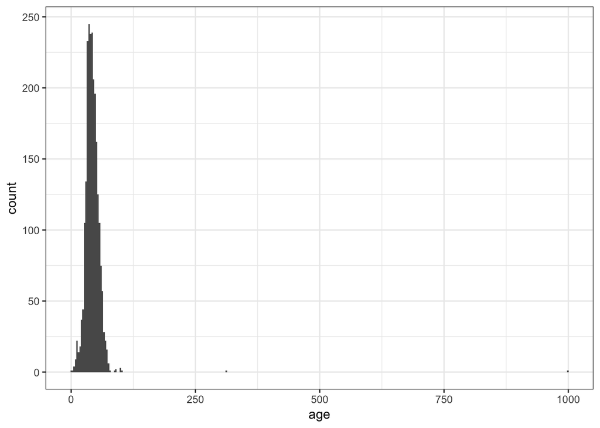

```r
ggplot(candy, aes(age)) + geom_histogram(binwidth = 3) + theme_bw()
```

```r
candy <- candy %>% filter(age <= 122)
nrow(candy)
```

```
## [1] 2350
```

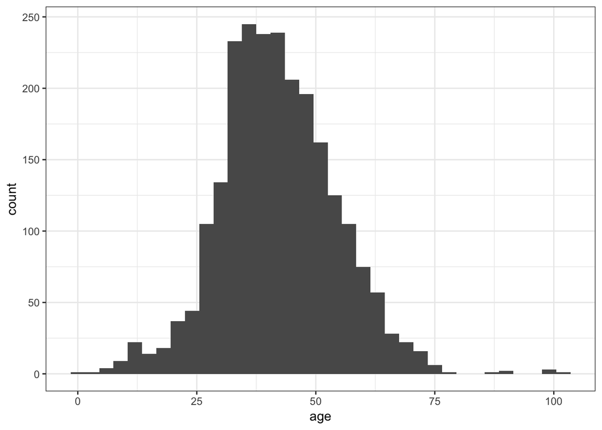

```r
ggplot(candy, aes(age)) + geom_histogram(binwidth = 3) + theme_bw()
```

Much better.

Note that there were some responses with age == 1 as well, but let’s ignore those for now. Let’s go with the naive assumption that maybe they will balance out with the supposed 100 year olds in our data.

### 3. How do respondents feel about each candy?

First, let’s look at the candy level, ignoring any associations between them. How are each of them rated?

Here, make a new data frame (candy_feelings), using “gather” to change the dataframe into a long format (candy and sentiment as columns). Convert any candy names and sentiments from character type to factors, just in case.

```r
candy_feelings <- gather(candy %>% select(candy_names), key="candy",value="sentiment") %>% mutate(sentiment=as.factor(sentiment)) %>% mutate(candy=as.factor(candy))

candy_feelings %>% head()
```

```
##               candy sentiment
## 1 hundred_grand_bar       MEH
## 2 hundred_grand_bar      <NA>
## 3 hundred_grand_bar       MEH
## 4 hundred_grand_bar       JOY
## 5 hundred_grand_bar      <NA>
## 6 hundred_grand_bar       JOY
```

How do people generally feel about candy?

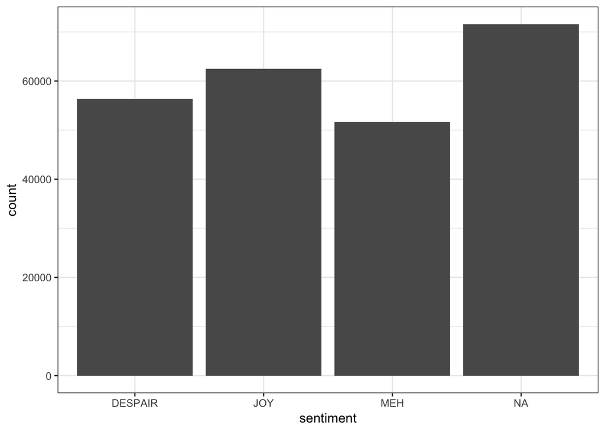

```r
ggplot(candy_feelings, aes(sentiment)) + geom_histogram(stat="count") + theme_bw()
```

There’s a pretty even distribution of feelings overall. No one sentiment dominates. NA’s might indicate that there are candies on the list people don’t know enough about to select a response (there are some pretty obscure ones!).

We can also count how many of each feeling each candy receives:

```r
candy_feelings %>% group_by(candy,sentiment) %>% tally()
```

```
## # A tibble: 412 x 3
## # Groups:   candy [?]
##    candy                                                   sentiment     n
##    <fct>                                                   <fct>     <int>
##  1 abstained_from_m_ming                                   DESPAIR     671
##  2 abstained_from_m_ming                                   JOY         213
##  3 abstained_from_m_ming                                   MEH         593
##  4 abstained_from_m_ming                                   <NA>        873
##  5 anonymous_brown_globs_that_come_in_black_and_orange_wr… DESPAIR    1053
##  6 anonymous_brown_globs_that_come_in_black_and_orange_wr… JOY         172
##  7 anonymous_brown_globs_that_come_in_black_and_orange_wr… MEH         449
##  8 anonymous_brown_globs_that_come_in_black_and_orange_wr… <NA>        676
##  9 any_full_sized_candy_bar                                DESPAIR      16
## 10 any_full_sized_candy_bar                                JOY        1514
## # ... with 402 more rows
```

To compare between candies, we’ll quantify each feeling. “Joy” receives a score of 1, “Despair” -1, and “Meh”s will be assigned a score of -0.01. (Note that in the original plot in [Science Creative Quarterly](http://www.scq.ubc.ca/so-much-candy-data-seriously/), the “Meh” votes are ignored; instead, a “Net feelies” measurement was defined as = #Joy - #Despair)

```r
candy_feelings_quantified <- candy_feelings %>%
  mutate(score=case_when(sentiment == "JOY" ~ 1,
                         sentiment == "DESPAIR" ~ -1,
                         sentiment == "MEH" ~ -0.01)) %>%
  group_by(candy) %>% summarise(score = sum(score,na.rm=TRUE))

arrange(candy_feelings_quantified, desc(score))
```

```
## # A tibble: 103 x 2
##    candy                               score
##    <fct>                               <dbl>
##  1 any_full_sized_candy_bar            1496.
##  2 reese_s_peanut_butter_cups          1361.
##  3 kit_kat                             1346.
##  4 cash_or_other_forms_of_legal_tender 1333.
##  5 twix                                1306.
##  6 snickers                            1276.
##  7 tolberone_something_or_other        1201.
##  8 lindt_truffle                       1137.
##  9 peanut_m_m_s                        1136.
## 10 nestle_crunch                       1059.
## # ... with 93 more rows
```

The top scoring candies are:

```r
arrange(candy_feelings_quantified, desc(score)) %>% pull(candy) %>% head(10)
```

```
##  [1] any_full_sized_candy_bar
##  [2] reese_s_peanut_butter_cups
##  [3] kit_kat
##  [4] cash_or_other_forms_of_legal_tender
##  [5] twix
##  [6] snickers
##  [7] tolberone_something_or_other
##  [8] lindt_truffle
##  [9] peanut_m_m_s
## [10] nestle_crunch
## 103 Levels: abstained_from_m_ming ...
```

And the bottom scoring candies are:

```r
arrange(candy_feelings_quantified, score)  %>% pull(candy) %>% head(10)
```

```
##  [1] broken_glow_stick
##  [2] gum_from_baseball_cards
##  [3] white_bread
##  [4] real_housewives_of_orange_county_season_9_blue_ray
##  [5] dental_paraphenalia
##  [6] kale_smoothie
##  [7] candy_that_is_clearly_just_the_stuff_given_out_for_free_at_restaurants
##  [8] whole_wheat_anything
##  [9] creepy_religious_comics_chick_tracts
## [10] boxo_raisins
## 103 Levels: abstained_from_m_ming ...
```

Most of the bottom scoring “candies” aren’t candies at all. Unsurprisingly, broken glow sticks and gum from baseball cards are the two worst rated.

Let’s plot them to get a visual representation here.

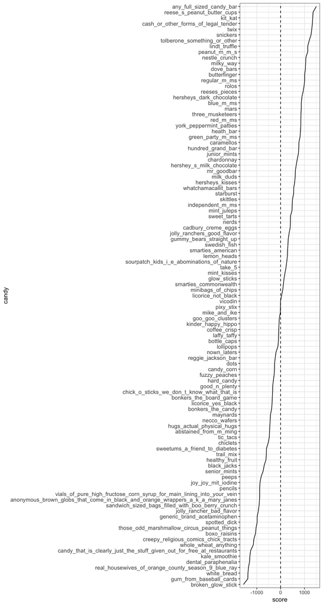

```r
ggplot(candy_feelings_quantified %>% mutate(candy=reorder(candy,score)), # here, reorder factors so it plots from small to large score
       aes(y=candy,x=score, group="none")) +
  geom_line() +
  theme_bw() + theme(axis.text.y = element_text(size=10)) +
  geom_vline(xintercept=0,linetype=2)
```

I don’t know about you, but I’m horrified that Coffee Crisps have a lower rating than Vicodin.

On that note, what is wrong with people who don’t like Coffee Crisp? Let’s do some more analysis on Coffee Crisps in particular. Is liking or disliking Coffee Crisps somehow related to liking any of the other variables?

First, let’s wrangle the data into something that we can work with. Here, we create a list of data frames, where each data frame is the score of another candy, computed separately for groups of people who rated Coffee Crisps with “JOY”, “DESPAIR”, and “MEH” (normalized for the number of people in each category):

```r
candy_of_interest <- "coffee_crisp"
other_candy <- str_subset(candy_names, pattern="[^coffee_crisp]") # character vector of all other candy

dfs <- list() # start out with an empty list
for (i in 1:length(other_candy)){
  score_name <- paste0(other_candy[i],"_score") # create name for new column (candy score)
  x <- candy %>% select_(candy_of_interest,other_candy[i]) %>%
        mutate(score=case_when(!!sym(other_candy[i]) == "JOY" ~ 1, # as before, change the rating to numerical weights
                               !!sym(other_candy[i]) == "DESPAIR" ~ -1,
                               !!sym(other_candy[i]) == "MEH" ~ -0.01)) %>%
        group_by_(candy_of_interest) %>%  # group by values in candy_of_interest (ie. coffee crisp)
    summarise(!!score_name:= sum(score,na.rm=TRUE)/n()) # and compute the score for the other candy (normalized for the number of people in each category)
  dfs[[i]] <- x # add this new data frame to the list
}

dfs[[1]]
```

```
## # A tibble: 4 x 2
##   coffee_crisp hundred_grand_bar_score
##   <chr>                          <dbl>
## 1 DESPAIR                       0.388
## 2 JOY                           0.434
## 3 MEH                           0.497
## 4 <NA>                          0.0904
```

Use the reduce() function to join together all the dataframes we created, joining on the coffee_crisp column. Now we have scores for all other candies, grouped by whether those people liked or disliked Coffee Crisps.

```r
(q <- reduce(dfs,left_join,by=candy_of_interest))
```

```
## # A tibble: 4 x 101
##   coffee_crisp hundred_grand_b… anonymous_brown… any_full_sized_…
##   <chr>                   <dbl>            <dbl>            <dbl>
## 1 DESPAIR                0.388            -0.638            0.828
## 2 JOY                    0.434            -0.397            0.898
## 3 MEH                    0.497            -0.497            0.845
## 4 <NA>                   0.0904           -0.102            0.205
## # ... with 97 more variables: black_jacks_score <dbl>,
## #   bonkers_the_candy_score <dbl>, bonkers_the_board_game_score <dbl>,
## #   bottle_caps_score <dbl>, boxo_raisins_score <dbl>,
## #   broken_glow_stick_score <dbl>, butterfinger_score <dbl>,
## #   cadbury_creme_eggs_score <dbl>, candy_corn_score <dbl>,
## #   candy_that_is_clearly_just_the_stuff_given_out_for_free_at_restaurants_score <dbl>,
## #   caramellos_score <dbl>,
## #   cash_or_other_forms_of_legal_tender_score <dbl>,
## #   chardonnay_score <dbl>,
## #   chick_o_sticks_we_don_t_know_what_that_is_score <dbl>,
## #   chiclets_score <dbl>,
## #   creepy_religious_comics_chick_tracts_score <dbl>,
## #   dental_paraphenalia_score <dbl>, dots_score <dbl>,
## #   dove_bars_score <dbl>, fuzzy_peaches_score <dbl>,
## #   generic_brand_acetaminophen_score <dbl>, glow_sticks_score <dbl>,
## #   goo_goo_clusters_score <dbl>, good_n_plenty_score <dbl>,
## #   gum_from_baseball_cards_score <dbl>,
## #   gummy_bears_straight_up_score <dbl>, hard_candy_score <dbl>,
## #   healthy_fruit_score <dbl>, heath_bar_score <dbl>,
## #   hersheys_dark_chocolate_score <dbl>,
## #   hershey_s_milk_chocolate_score <dbl>, hersheys_kisses_score <dbl>,
## #   hugs_actual_physical_hugs_score <dbl>,
## #   jolly_rancher_bad_flavor_score <dbl>,
## #   jolly_ranchers_good_flavor_score <dbl>,
## #   joy_joy_mit_iodine_score <dbl>, junior_mints_score <dbl>,
## #   senior_mints_score <dbl>, kale_smoothie_score <dbl>,
## #   kinder_happy_hippo_score <dbl>, kit_kat_score <dbl>,
## #   laffy_taffy_score <dbl>, lemon_heads_score <dbl>,
## #   licorice_not_black_score <dbl>, licorice_yes_black_score <dbl>,
## #   lindt_truffle_score <dbl>, lollipops_score <dbl>, mars_score <dbl>,
## #   maynards_score <dbl>, mike_and_ike_score <dbl>, milk_duds_score <dbl>,
## #   milky_way_score <dbl>, regular_m_ms_score <dbl>,
## #   peanut_m_m_s_score <dbl>, blue_m_ms_score <dbl>, red_m_ms_score <dbl>,
```

[output cut: 10 more lines]

```
## #   skittles_score <dbl>, smarties_american_score <dbl>,
## #   smarties_commonwealth_score <dbl>, snickers_score <dbl>,
## #   sourpatch_kids_i_e_abominations_of_nature_score <dbl>,
## #   spotted_dick_score <dbl>, starburst_score <dbl>,
## #   sweet_tarts_score <dbl>, swedish_fish_score <dbl>,
## #   sweetums_a_friend_to_diabetes_score <dbl>, take_5_score <dbl>,
## #   tic_tacs_score <dbl>,
## #   those_odd_marshmallow_circus_peanut_things_score <dbl>,
## #   three_musketeers_score <dbl>,
## #   tolberone_something_or_other_score <dbl>, trail_mix_score <dbl>,
## #   twix_score <dbl>,
## #   vials_of_pure_high_fructose_corn_syrup_for_main_lining_into_your_vein_score <dbl>,
## #   vicodin_score <dbl>, whatchamacallit_bars_score <dbl>,
## #   white_bread_score <dbl>, whole_wheat_anything_score <dbl>,
## #   york_peppermint_patties_score <dbl>
```

Again, these scores were computed separately for groups of people who rated Coffee Crisps with “DESPAIR”, “JOY”, and “MEH” (shown as different columns in the heat map below).

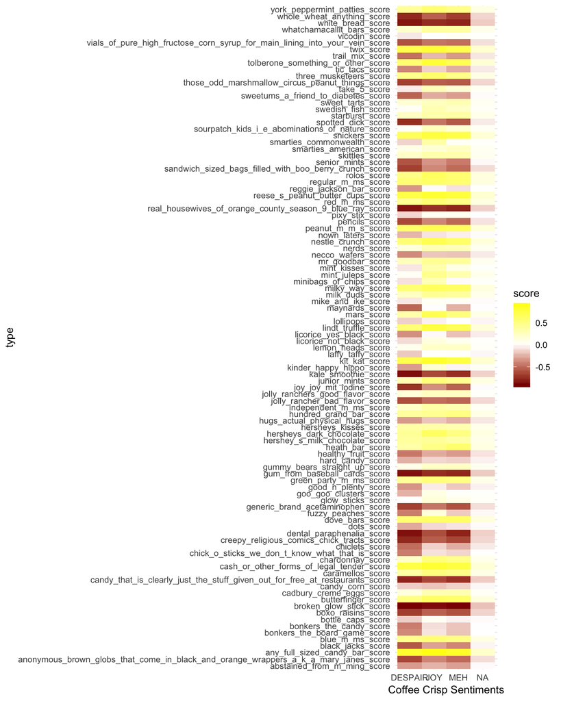

```r
to_plot <- q %>% gather(key="type",value="score",2:length(q)) # transform data into a long format for ggplot

ggplot(data = to_plot, aes(x = coffee_crisp, y = type)) + # coffee_crisp sentiments on the x axis, and other candies on the y acis
  geom_tile(aes(fill = score)) + # colours indicate scores computed for each candy
  scale_fill_gradient2(low="darkred", high="yellow", guide="colorbar") +
  xlab("Coffee Crisp Sentiments") +
  theme_minimal()
```

Some types of candies (any full sized candy bars, kit kats, cash, Reese’s peanut butter cups, etc.) everyone seems to like, no matter whether they like coffee crisps or not.

On the other hand, the heat maps shows some candies that have different scores between the people who like vs dislike (react with “joy” or “despair” to) Coffee Crisps.

# Part Two: Trump Tweets (Topic #5)

Using Jenny Bryan’s [purrr tutorial](https://jennybc.github.io/purrr-tutorial/ls08_trump-tweets.html) as a guide, we load and analyse Trump tweets, extracting words from commonly tweeted from Trump’s ([angrier](http://varianceexplained.org/r/trump-tweets/)) Android device.

In this exercise, we’ll:

1. Walk through the steps in the purrr tutorial to analyse all of Trump’s twitter data in our dataset
2. Pull out any other interesting things in Trump’s twitter data

Load the data, downloaded from http://varianceexplained.org/files/trump_tweets_df.rda (2016 twitter data).

```r
load("trump_tweets_df.rda")
glimpse(trump_tweets_df)
```

```
## Observations: 1,512
## Variables: 16
## $ text          <chr> "My economic policy speech will be carried live ...
## $ favorited     <lgl> FALSE, FALSE, FALSE, FALSE, FALSE, FALSE, FALSE,...
## $ favoriteCount <dbl> 9214, 6981, 15724, 19837, 34051, 29831, 19223, 1...
## $ replyToSN     <chr> NA, NA, NA, NA, NA, NA, NA, NA, NA, NA, NA, NA, ...
## $ created       <dttm> 2016-08-08 15:20:44, 2016-08-08 13:28:20, 2016-...
## $ truncated     <lgl> FALSE, FALSE, FALSE, FALSE, FALSE, FALSE, FALSE,...
## $ replyToSID    <lgl> NA, NA, NA, NA, NA, NA, NA, NA, NA, NA, NA, NA, ...
## $ id            <chr> "762669882571980801", "762641595439190016", "762...
## $ replyToUID    <chr> NA, NA, NA, NA, NA, NA, NA, NA, NA, NA, NA, NA, ...
## $ statusSource  <chr> "<a href=\"http://twitter.com/download/android\"...
## $ screenName    <chr> "realDonaldTrump", "realDonaldTrump", "realDonal...
## $ retweetCount  <dbl> 3107, 2390, 6691, 6402, 11717, 9892, 5784, 7930,...
## $ isRetweet     <lgl> FALSE, FALSE, FALSE, FALSE, FALSE, FALSE, FALSE,...
## $ retweeted     <lgl> FALSE, FALSE, FALSE, FALSE, FALSE, FALSE, FALSE,...
## $ longitude     <chr> NA, NA, NA, NA, NA, NA, NA, NA, NA, NA, NA, NA, ...
## $ latitude      <chr> NA, NA, NA, NA, NA, NA, NA, NA, NA, NA, NA, NA, ...
```

Let’s look at the text in particular. (Preview using head() and strtrim())

```r
all_tweets <- trump_tweets_df$text
all_tweets %>% head() %>% strtrim(70)
```

```
## [1] "My economic policy speech will be carried live at 12:15 P.M. Enjoy!"
## [2] "Join me in Fayetteville, North Carolina tomorrow evening at 6pm. Ticke"
## [3] "#ICYMI: \"Will Media Apologize to Trump?\" https://t.co/ia7rKBmioA"
## [4] "Michael Morell, the lightweight former Acting Director of C.I.A., and "
## [5] "The media is going crazy. They totally distort so many things on purpo"
## [6] "I see where Mayor Stephanie Rawlings-Blake of Baltimore is pushing Cro"
```

Let’s check when these tweets were collected:

```r
dates <- trump_tweets_df$created
dates[order(format(as.Date(dates),"%y%m%d"))[1]]
```

```
## [1] "2015-12-14 21:11:12 UTC"
```

```r
dates[order(format(as.Date(dates),"%y%m%d"))[length(dates)]]
```

```
## [1] "2016-08-08 00:05:54 UTC"
```

It seems like these tweets were created at the end of 2015 to August 2016– during Trump’s campaign leading up the presidential election.

### 1. Using purrr

According to [Jenny](https://jennybc.github.io/purrr-tutorial/ls08_trump-tweets.html), words that were shown to be associated with Trump tweets from an Android device include “badly”,“crazy”,“weak”,“spent”,“strong”,“dumb”,“joke”,“guns”,“funny”, and “dead”.

We store these as a regular expression, to be used later. Our goal is to extract these words from each tweet, so that we can count them later and conduct further analyses.

```r
regex <- "badly|crazy|weak|spent|strong|dumb|joke|guns|funny|dead"
```

Now, do those tweets contain any of the words in regex? Here, we use gregexpr() to filter through our vector of tweets (all_tweets)

We can interpret the output as the following: gregexpr outputs -1 if there are no matches. If there is at least one match, it outputs the integer of the position of the first character of each match.

The attribute “match.length” contains the length of each match (if there are matches).

```r
matches <- gregexpr(regex, all_tweets)
str(matches, list.len=10)
```

```
## List of 1512
##  $ : int -1
##   ..- attr(*, "match.length")= int -1
##  $ : int -1
##   ..- attr(*, "match.length")= int -1
##  $ : int -1
##   ..- attr(*, "match.length")= int -1
##  $ : int -1
##   ..- attr(*, "match.length")= int -1
##  $ : int 20
##   ..- attr(*, "match.length")= int 5
##  $ : int 134
##   ..- attr(*, "match.length")= int 4
##  $ : int -1
##   ..- attr(*, "match.length")= int -1
##  $ : int -1
##   ..- attr(*, "match.length")= int -1
##  $ : int -1
##   ..- attr(*, "match.length")= int -1
##  $ : int -1
##   ..- attr(*, "match.length")= int -1
##   [list output truncated]
```

To extract how many matches there are in each tweet in a single vector or list, we would need to sum up the number of elements that are not -1.

```r
num_matches <- map_int(matches, function(x) sum(x!=-1)) # or sum(x>0), used in Jenny Bryan's tutorial
#or map_int(match_lengths, function(x) sum(x!=-1))
num_matches %>% head()
```

```
## [1] 0 0 0 0 1 1
```

As a reminder, our goal is to extract certain words of interest in the tweets. To extract these words from each tweet, we need to use substring(). But substring() uses particular inputs, i.e. the position of the first and last character of the substring to extract from each tweet.

We’ll need to take the information needed from the “matches” list above, in a particular format, to feed into substring().

First, we’ll need to get the match lengths. To do this, we extract the attribute out from each element in the matches list.

```r
match_lengths <- map(matches, attr, which = "match.length")
match_lengths %>% head()
```

```
## [[1]]
## [1] -1
##
## [[2]]
## [1] -1
##
## [[3]]
## [1] -1
##
## [[4]]
## [1] -1
##
## [[5]]
## [1] 5
##
## [[6]]
## [1] 4
```

And what about the position of the matches? The “matches” list has those, but we don’t need all the attributes. Use as.vector() to strip those attributes.

```r
match_first <- map(matches, as.vector)
match_first %>% head()
```

```
## [[1]]
## [1] -1
##
## [[2]]
## [1] -1
##
## [[3]]
## [1] -1
##
## [[4]]
## [1] -1
##
## [[5]]
## [1] 20
##
## [[6]]
## [1] 134
```

Let’s test what we have so far with a single tweet, to make sure substring() works. Pick a tweet that has at least one match. Calculate the position of the last character of the match (t_last) by adding the position of the first, plus the length, minus one.

```r
i <- which(num_matches>0)[1] # pick a tweet that has at least one match

(tweet <- all_tweets[i])
```

```
## [1] "The media is going crazy. They totally distort so many things on purpose. Crimea, nuclear, \"the baby\" and so much more. Very dishonest!"
```

```r
(t_first <- match_first[[i]])
```

```
## [1] 20
```

```r
t_length <- match_lengths[[i]]
(t_last <- t_first + t_length - 1)
```

```
## [1] 24
```

```r
substring(tweet, t_first, t_last)
```

```
## [1] "crazy"
```

How about a tweet that has multiple matches? Does substring() still work?

```r
i <- which(num_matches>=2)[1] # pick a tweet that has at least 2 matches

(tweet <- all_tweets[i])
```

```
## [1] "Bernie Sanders started off strong, but with the selection of Kaine for V.P., is ending really weak. So much for a movement! TOTAL DISRESPECT"
```

```r
(t_first <- match_first[[i]])
```

```
## [1] 28 95
```

```r
t_length <- match_lengths[[i]]
(t_last <- t_first + t_length - 1)
```

```
## [1] 33 98
```

```r
substring(tweet, t_first, t_last)
```

```
## [1] "strong" "weak"
```

For a tweet with multiple of interest, substring seems to be able to pick up on all the words. (substring() can take in vector data for the first and last character arguments!)

How about for 0 words of interest?

```r
i <- which(num_matches==0)[1] # pick a tweet that has no matches

(tweet <- all_tweets[i])
```

```
## [1] "My economic policy speech will be carried live at 12:15 P.M. Enjoy!"
```

```r
t_first <- match_first[[i]]
t_length <- match_lengths[[i]]
t_last <- t_first + t_length - 1
substring(tweet, t_first, t_last)
```

```
## [1] ""
```

We get an empty string for a tweet with 0 words of interest. Great!

Let’s put this all together, so that we don’t have to run substring() separately for each tweet. To do this, we again make use of the purrr package and work with just lists.

Instead of calculating the last character (t_last) every time we get a single tweet, let’s make a list similar to match_first and match_lengths.

We do this using map2(), which allows us to map over 2 lists in parallel.

```r
match_last <- map2(match_first,match_lengths,function(x,y) ifelse(x!=-1,x+y-1,-1))
match_last %>% head()
```

```
## [[1]]
## [1] -1
##
## [[2]]
## [1] -1
##
## [[3]]
## [1] -1
##
## [[4]]
## [1] -1
##
## [[5]]
## [1] 24
##
## [[6]]
## [1] 137
```

Now we have 3 lists, with match_first and match_last satisfying the arguments that need to go into substring().

We want to apply substring() to the lists all_tweets, match_first, and match_last, but we now have 3 lists to map over, so map2() will not work. Instead, we use pmap() - which takes in the list of lists we want to map over in parallel.

```r
pmap(list(text=all_tweets,first = match_first, last = match_last), substring) %>% head()
```

```
## [[1]]
## [1] ""
##
## [[2]]
## [1] ""
##
## [[3]]
## [1] ""
##
## [[4]]
## [1] ""
##
## [[5]]
## [1] "crazy"
##
## [[6]]
## [1] "joke"
```

It works!

Alternatively, pmap() can take in a dataframe (which is, in fact, just a list of equal length lists!):

```r
mdf <- tibble(
  text = all_tweets,
  first = match_first,
  last = match_last
)
pmap(mdf, substring) %>% head()
```

```
## [[1]]
## [1] ""
##
## [[2]]
## [1] ""
##
## [[3]]
## [1] ""
##
## [[4]]
## [1] ""
##
## [[5]]
## [1] "crazy"
##
## [[6]]
## [1] "joke"
```

Or, if we want to put all the steps together using pipes (%>%), we could have done this in the following way:

```r
tibble(text = all_tweets,
       first = gregexpr(regex, all_tweets)) %>%
  mutate(match_length = map(first, ~ attr(.x, which = "match.length")),
         last = map2(first, match_length, ~ .x + .y - 1)) %>%
  select(-match_length) %>%
  pmap(substring) %>% head()
```

```
## [[1]]
## [1] ""
##
## [[2]]
## [1] ""
##
## [[3]]
## [1] ""
##
## [[4]]
## [1] ""
##
## [[5]]
## [1] "crazy"
##
## [[6]]
## [1] "joke"
```

Next, let’s step it up and generalize this as function.

First we’ll make a function that takes in twitter data (text only, as a character vector) and words of interest (as a regular expression) and puts out a dataframe with columns:

- text, - match_first, - match_last, - n_matches (number of matches in each tweet), and - match_words (extracted matching words)

```r
filter_tweets <- function(tweets,words){
  tibble(text = tweets,
                 match_first = gregexpr(words, tweets)) %>%
  mutate(match_length = map(match_first, ~ attr(.x, which = "match.length")),
         match_last = map2(match_first, match_length, ~ .x + .y - 1),
         n_matches = map_int(match_first, function(x) sum(x>0))) %>%
  select(-match_length) %>%
    mutate(match_words = pmap(list(text=tweets,first = match_first, last = match_last),substring))
}
```

Test out our function:

```r
words <- "badly|crazy|weak|spent|strong|dumb|joke|guns|funny|dead"
tweetdf <- filter_tweets(all_tweets,words)
tweetdf %>% head()
```

```
## # A tibble: 6 x 5
##   text                        match_first match_last n_matches match_words
##   <chr>                       <list>      <list>         <int> <list>
## 1 My economic policy speech … <int [1]>   <dbl [1]>          0 <chr [1]>
## 2 Join me in Fayetteville, N… <int [1]>   <dbl [1]>          0 <chr [1]>
## 3 "#ICYMI: \"Will Media Apol… <int [1]>   <dbl [1]>          0 <chr [1]>
## 4 Michael Morell, the lightw… <int [1]>   <dbl [1]>          0 <chr [1]>
## 5 "The media is going crazy.… <int [1]>   <dbl [1]>          1 <chr [1]>
## 6 I see where Mayor Stephani… <int [1]>   <dbl [1]>          1 <chr [1]>
```

Test that we can still extract the matching words, as before:

```r
tweetdf %>% filter(n_matches>0) %>% pull(match_words) %>% head()
```

```
## [[1]]
## [1] "crazy"
##
## [[2]]
## [1] "joke"
##
## [[3]]
## [1] "badly"
##
## [[4]]
## [1] "joke"
##
## [[5]]
## [1] "weak"
##
## [[6]]
## [1] "dumb"
```

Now, could we slightly modify our function so that it takes in a dataframe (containing a column called “text”), instead of just a character vector of text? This way, we don’t need to create a new dataframe with tibble(), and we can simply use pipes to modify the existing dataframe.

```r
filter_tweets2 <- function(tweetdf,words){
  tweetdf %>%
    mutate(match_first = gregexpr(words, text),
         match_length = map(match_first, ~ attr(.x, which = "match.length")),
         match_last = map2(match_first, match_length, ~ .x + .y - 1),
         n_matches = map_int(match_first, function(x) sum(x>0))) %>%
    select(-match_length) %>%
    mutate(match_words = pmap(list(text=text,first = match_first, last = match_last),substring))
}
```

This modified function would allow us to use the original trump_tweets_df dataframe, which turns out to have lots more metadata, including retweet counts and “status source”, which indicates which device (Android or iPhone) the tweet comes from:

```r
trump_tweets_df %>% head()
```

```
## # A tibble: 6 x 16
##   text  favorited favoriteCount replyToSN created             truncated
##   <chr> <lgl>             <dbl> <chr>     <dttm>              <lgl>
## 1 My e… FALSE              9214 <NA>      2016-08-08 15:20:44 FALSE
## 2 Join… FALSE              6981 <NA>      2016-08-08 13:28:20 FALSE
## 3 "#IC… FALSE             15724 <NA>      2016-08-08 00:05:54 FALSE
## 4 Mich… FALSE             19837 <NA>      2016-08-07 23:09:08 FALSE
## 5 "The… FALSE             34051 <NA>      2016-08-07 21:31:46 FALSE
## 6 I se… FALSE             29831 <NA>      2016-08-07 13:49:29 FALSE
## # ... with 10 more variables: replyToSID <lgl>, id <chr>,
## #   replyToUID <chr>, statusSource <chr>, screenName <chr>,
## #   retweetCount <dbl>, isRetweet <lgl>, retweeted <lgl>, longitude <chr>,
## #   latitude <chr>
```

But since we don’t need *all* the information in that dataframe, let’s select the columns we’re interested in, before feeding it into our filter_tweets2() function.

```r
all_tweets2 <- trump_tweets_df %>%
  select(statusSource, retweetCount, text) %>%
  extract(statusSource, "source", "Twitter for (.*?)<") %>%
  filter(source %in% c("iPhone","Android"))

words <- "badly|crazy|weak|spent|strong|dumb|joke|guns|funny|dead"
filter_tweets2(all_tweets2,words) %>% head()
```

```
## # A tibble: 6 x 7
##   source  retweetCount text   match_first match_last n_matches match_words
##   <chr>          <dbl> <chr>  <list>      <list>         <int> <list>
## 1 Android         3107 My ec… <int [1]>   <dbl [1]>          0 <chr [1]>
## 2 iPhone          2390 Join … <int [1]>   <dbl [1]>          0 <chr [1]>
## 3 iPhone          6691 "#ICY… <int [1]>   <dbl [1]>          0 <chr [1]>
## 4 Android         6402 Micha… <int [1]>   <dbl [1]>          0 <chr [1]>
## 5 Android        11717 "The … <int [1]>   <dbl [1]>          1 <chr [1]>
## 6 Android         9892 I see… <int [1]>   <dbl [1]>          1 <chr [1]>
```

Inspired by [the original article by David Robinson](http://varianceexplained.org/r/trump-tweets/), let’s compare between Trump’s Android and iPhone tweets. People have speculated that Trump’s own tweets come from an Android device, while his campaign staff had an iPhone.

How many total tweets are from Android vs iPhone?

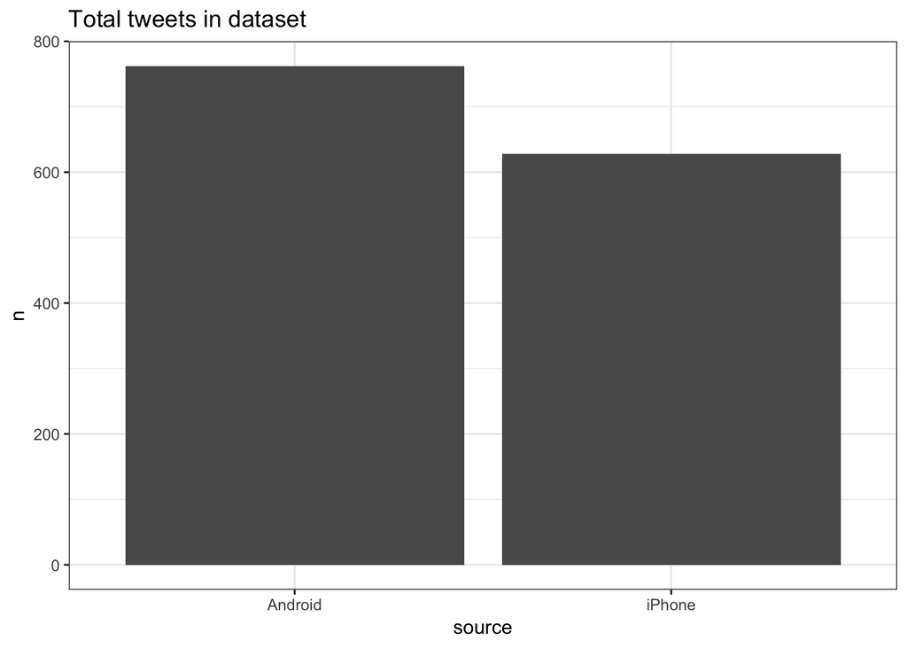

```r
all_tweets2  %>%
  group_by(source) %>% tally() %>%
  ggplot(aes(x=source,y=n)) + geom_bar(stat="identity") + theme_bw() + ggtitle("Total tweets in dataset")
```

How do the retweets compare between the two? (To do this, we sum the retweet counts in each category, and normalize by number of tweets in each category)

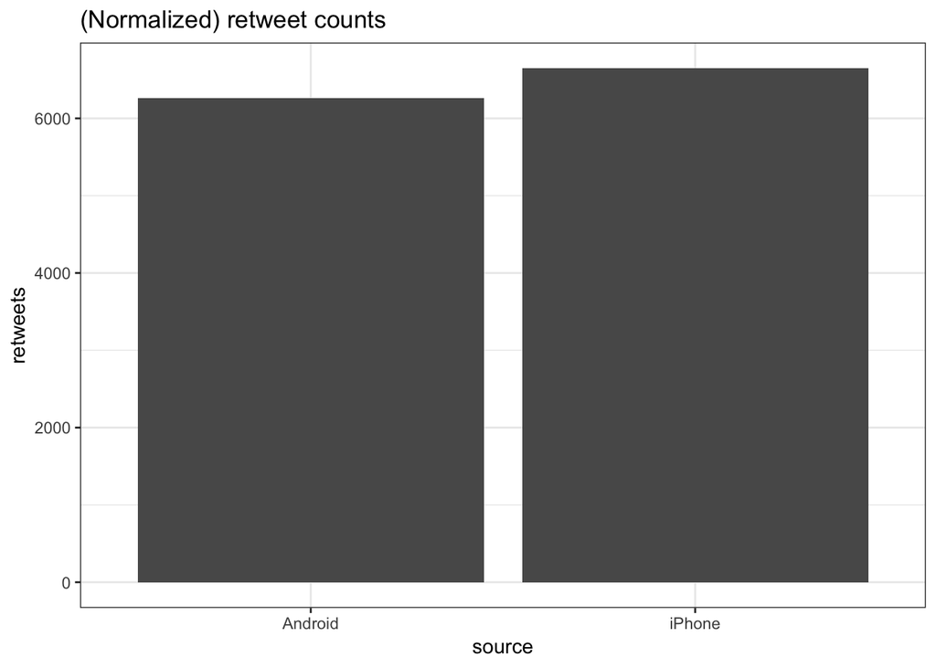

```r
all_tweets2  %>%
  group_by(source) %>% summarize(retweets=sum(retweetCount)/n()) %>%
  ggplot(aes(x=source,y=retweets)) + geom_bar(stat="identity") + theme_bw() + ggtitle("(Normalized) retweet counts")
```

How many matches are in tweets from Android vs iPhone? Is it true that those words in our regular expression are coming from primarily Android tweets?

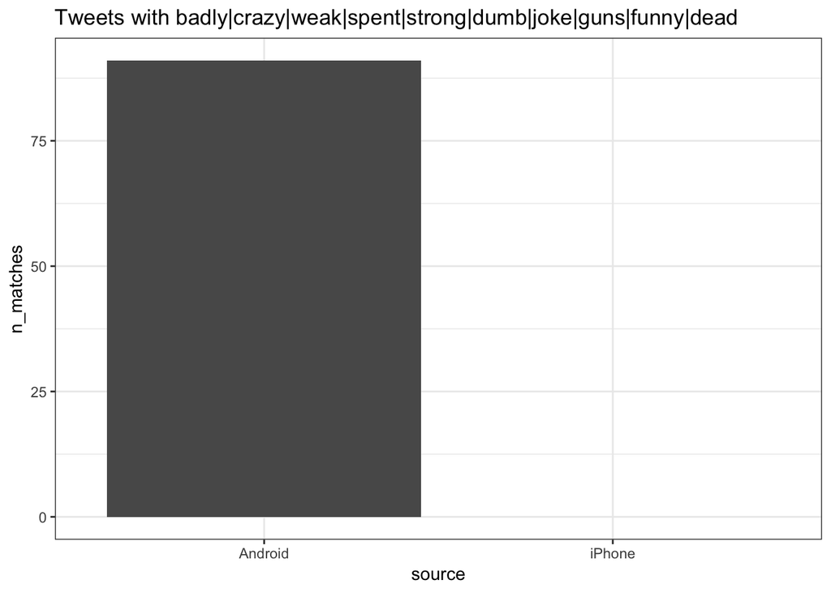

```r
all_tweets2  %>% filter_tweets2(words)  %>%
  group_by(source) %>% summarise(n_matches = sum(n_matches)) %>%
  ggplot(aes(x=source,y=n_matches)) + geom_bar(stat="identity") + theme_bw() + ggtitle(paste("Tweets with",words))
```

Let’s try filtering out different (Trump speech-like) words now, and compare between Android and iPhone tweets.

```r
w <- "sad|Sad|SAD"
all_tweets2  %>% filter_tweets2(.,w) %>% filter(n_matches>0) %>% pull(text) %>% head()
```

```
## [1] "The media coverage this morning of the very average Clinton speech and Convention is a joke. @CNN and the little watched @Morning_Joe = SAD!"
## [2] "The Democratic Convention has paid ZERO respect to the great police and law enforcement professionals of our country. No recognition - SAD!"
## [3] "Pocahontas bombed last night! Sad to watch."
## [4] "Sad to watch Bernie Sanders abandon his revolution. We welcome all voters who want to fix our rigged system and bring back our jobs."
## [5] "Sorry folks, but Bernie Sanders is exhausted, just can't go on any longer. He is trying to dismiss the new e-mails and DNC disrespect. SAD!"
## [6] "Despite spending $500k a day on TV ads alone #CrookedHillary falls flat in nationwide @QuinnipiacPoll. Having ZERO impact. Sad!!"
```

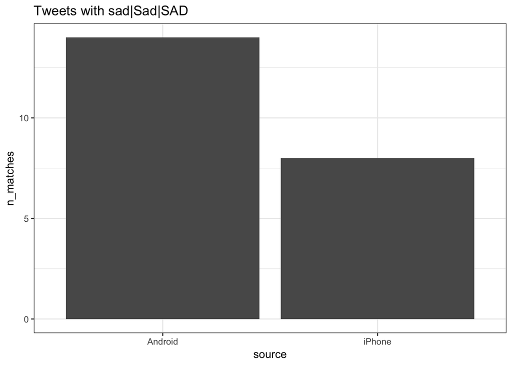

```r
all_tweets2  %>% filter_tweets2(.,w) %>%
  group_by(source) %>% summarise(n_matches = sum(n_matches)) %>%
  ggplot(aes(x=source,y=n_matches)) + geom_bar(stat="identity") + theme_bw() + ggtitle(paste("Tweets with",w))
```

It’s interesting that “sad” appears in both Android (speculated to be Trump) and iPhone (speculated to be his staff) tweets. How about just “SAD” in all capitals?

```r
w <- "SAD"
all_tweets2  %>% filter_tweets2(.,w) %>% filter(n_matches>0) %>% pull(text) %>% head()
```

```
## [1] "The media coverage this morning of the very average Clinton speech and Convention is a joke. @CNN and the little watched @Morning_Joe = SAD!"
## [2] "The Democratic Convention has paid ZERO respect to the great police and law enforcement professionals of our country. No recognition - SAD!"
## [3] "Sorry folks, but Bernie Sanders is exhausted, just can't go on any longer. He is trying to dismiss the new e-mails and DNC disrespect. SAD!"
## [4] "Why is it that the horrendous protesters, who scream, curse punch, shut down roads/doors during my RALLIES,  are never blamed by media? SAD!"
```

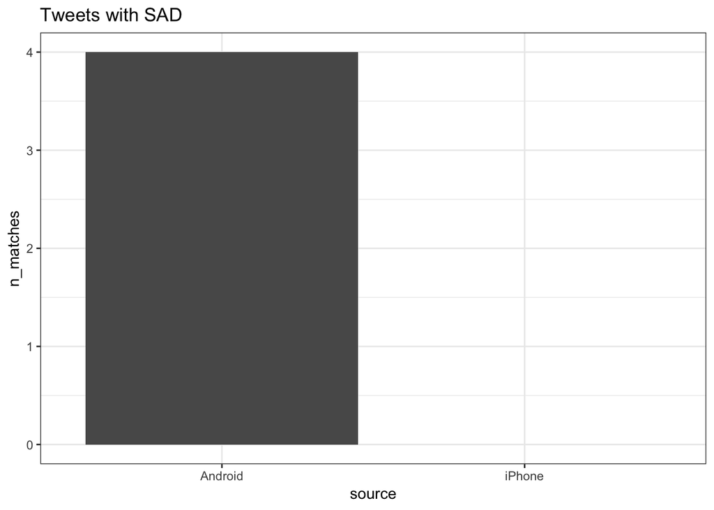

```r
all_tweets2  %>% filter_tweets2(.,w) %>%
  group_by(source) %>% summarise(n_matches = sum(n_matches)) %>%
  ggplot(aes(x=source,y=n_matches)) + geom_bar(stat="identity") + theme_bw() + ggtitle(paste("Tweets with",w))
```

“SAD” in all capitals seems to be just the Android tweets (n=4).

How about guns?

```r
w <- "guns|Guns|GUNS"
all_tweets2  %>% filter_tweets2(.,w) %>% filter(n_matches>0) %>% pull(text) %>% head()
```

```
## [1] "When I said that if, within the Orlando club, you had some people with guns, I was obviously talking about additional guards or employees"
## [2] "I will be meeting with the NRA, who has endorsed me, about not allowing people on the terrorist watch list, or the no fly list, to buy guns."
## [3] "Crooked Hillary Clinton will be a disaster on jobs, the economy, trade, healthcare, the military, guns and just about all else. Obama plus!"
## [4] "Crooked Hillary said that I  want guns brought into the school classroom. Wrong!"
## [5] "\"@RBacliff: Hillary wants to rip the guns out of America's hands. No guns = no protection. Get on #TrumpTrain &amp; join @NRA to stop her.\""
## [6] "Crooked Hillary wants to get rid of all guns and yet she is surrounded by bodyguards who are fully armed. No more guns to protect Hillary!"
```

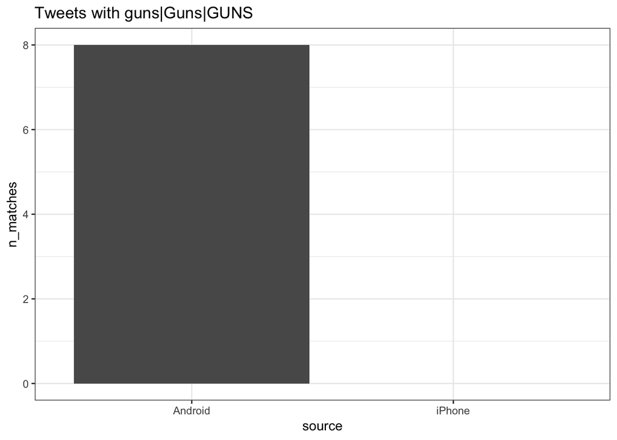

```r
all_tweets2  %>% filter_tweets2(.,w) %>%
  group_by(source) %>% summarise(n_matches = sum(n_matches)) %>%
  ggplot(aes(x=source,y=n_matches)) + geom_bar(stat="identity") + theme_bw() + ggtitle(paste("Tweets with",w))
```

Totally?

```r
w <- "totally|Totally|TOTALLY"
all_tweets2  %>% filter_tweets2(.,w) %>% filter(n_matches>0) %>% pull(text) %>% head()
```

```
## [1] "The media is going crazy. They totally distort so many things on purpose. Crimea, nuclear, \"the baby\" and so much more. Very dishonest!"
## [2] "I am not just running against Crooked Hillary Clinton, I am running against the very dishonest and totally biased media - but I will win!"
## [3] "Bernie Sanders totally sold out to Crooked Hillary Clinton. All of that work, energy and money, and nothing to show for it! Waste of time."
## [4] "While Bernie has totally given up on his fight for the people, we welcome all voters who want a better future for our workers."
## [5] "Arena was packed, totally electric!"
## [6] "Our country is totally divided and our enemies are watching. We are not looking good, we are not looking smart, we are not looking tough!"
```

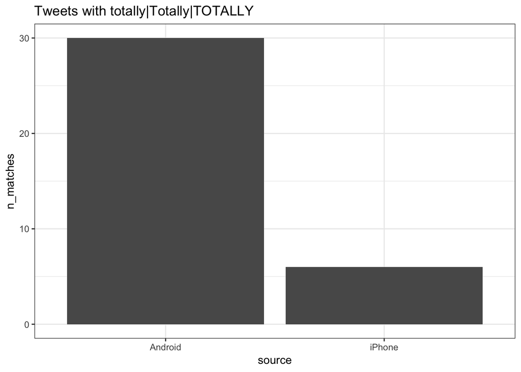

```r
all_tweets2  %>% filter_tweets2(.,w) %>%
  group_by(source) %>% summarise(n_matches = sum(n_matches)) %>%
  ggplot(aes(x=source,y=n_matches)) + geom_bar(stat="identity") + theme_bw() + ggtitle(paste("Tweets with",w))
```

And finally, how about tweets ending with an exclamation mark?

```r
w <- "[!]$"
all_tweets2  %>% filter_tweets2(.,w) %>% filter(n_matches>0) %>% pull(text) %>% head()
```

```
## [1] "My economic policy speech will be carried live at 12:15 P.M. Enjoy!"
## [2] "Michael Morell, the lightweight former Acting Director of C.I.A., and a man who has made serious bad calls, is a total Clinton flunky!"
## [3] "The media is going crazy. They totally distort so many things on purpose. Crimea, nuclear, \"the baby\" and so much more. Very dishonest!"
## [4] "I see where Mayor Stephanie Rawlings-Blake of Baltimore is pushing Crooked hard. Look at the job she has done in Baltimore. She is a joke!"
## [5] "I am not just running against Crooked Hillary Clinton, I am running against the very dishonest and totally biased media - but I will win!"
## [6] "Heading to New Hampshire - will be talking about Hillary saying her brain SHORT CIRCUITED, and other things!"
```

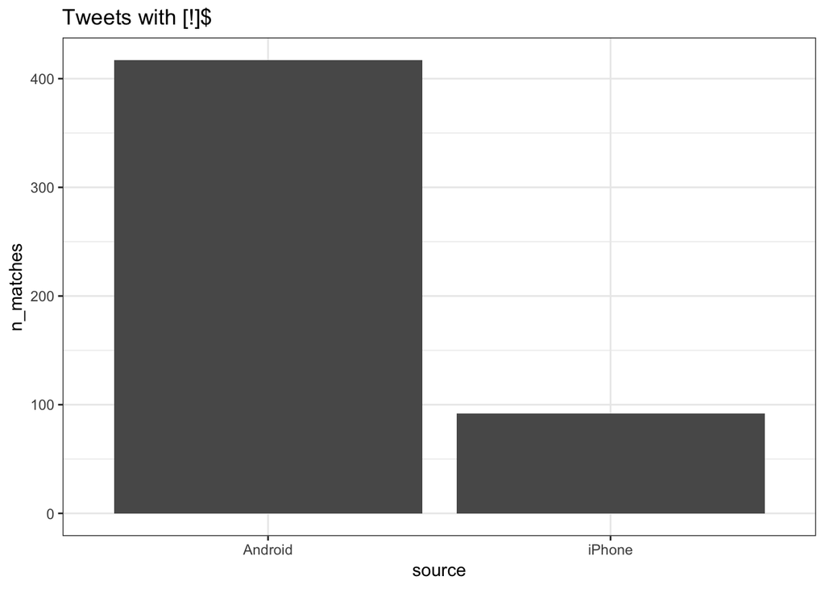

```r
all_tweets2  %>% filter_tweets2(.,w) %>%
  group_by(source) %>% summarise(n_matches = sum(n_matches)) %>%
  ggplot(aes(x=source,y=n_matches)) + geom_bar(stat="identity") + theme_bw() + ggtitle(paste("Tweets with",w))
```